# lab2_framingham_heart_study_r.Rmd

Thalie D-B

## Lab 2

# Accessing Data

This is data from the Framingham Heart Study.

```r
data_url <- paste0(
  "https://raw.githubusercontent.com/GauravPadawe/",
  "Framingham-Heart-Study/master/framingham.csv"
)

fram <- read.csv(data_url, na.strings = c("NA", ""))
```

# View data structure

```r
cat("Rows:", nrow(fram), "\n")
```

```
## Rows: 4240
```

```r
cat("Columns:", ncol(fram), "\n")
```

```
## Columns: 16
```

```r
head(fram)
```

```
##   male age education currentSmoker cigsPerDay BPMeds prevalentStroke
## 1    1  39         4             0          0      0               0
## 2    0  46         2             0          0      0               0
## 3    1  48         1             1         20      0               0
## 4    0  61         3             1         30      0               0
## 5    0  46         3             1         23      0               0
## 6    0  43         2             0          0      0               0
##   prevalentHyp diabetes totChol sysBP diaBP   BMI heartRate glucose TenYearCHD
## 1            0        0     195 106.0    70 26.97        80      77          0
## 2            0        0     250 121.0    81 28.73        95      76          0
## 3            0        0     245 127.5    80 25.34        75      70          0
## 4            1        0     225 150.0    95 28.58        65     103          1
## 5            0        0     285 130.0    84 23.10        85      85          0
## 6            1        0     228 180.0   110 30.30        77      99          0
```

```r
str(fram)
```

```
## 'data.frame':    4240 obs. of  16 variables:
##  $ male           : int  1 0 1 0 0 0 0 0 1 1 ...
##  $ age            : int  39 46 48 61 46 43 63 45 52 43 ...
##  $ education      : int  4 2 1 3 3 2 1 2 1 1 ...
##  $ currentSmoker  : int  0 0 1 1 1 0 0 1 0 1 ...
##  $ cigsPerDay     : int  0 0 20 30 23 0 0 20 0 30 ...
##  $ BPMeds         : int  0 0 0 0 0 0 0 0 0 0 ...
##  $ prevalentStroke: int  0 0 0 0 0 0 0 0 0 0 ...
##  $ prevalentHyp   : int  0 0 0 1 0 1 0 0 1 1 ...
##  $ diabetes       : int  0 0 0 0 0 0 0 0 0 0 ...
##  $ totChol        : int  195 250 245 225 285 228 205 313 260 225 ...
##  $ sysBP          : num  106 121 128 150 130 ...
##  $ diaBP          : num  70 81 80 95 84 110 71 71 89 107 ...
##  $ BMI            : num  27 28.7 25.3 28.6 23.1 ...
##  $ heartRate      : int  80 95 75 65 85 77 60 79 76 93 ...
##  $ glucose        : int  77 76 70 103 85 99 85 78 79 88 ...
##  $ TenYearCHD     : int  0 0 0 1 0 0 1 0 0 0 ...
```

# Check for missing values

```r
missing_n <- sort(colSums(is.na(fram)), decreasing = TRUE)
missing_n[missing_n > 0]
```

```
##    glucose  education     BPMeds    totChol cigsPerDay        BMI  heartRate
##        388        105         53         50         29         19          1
```

# Variable Analysis and Transformations

I chose to look at the variables for age, current smoker status and ten year CHD. I organized the data by creating age groups for age ranges and I created smoking status that translates the 0/1 data into no/yes, and established the display order. This is how I chose to display the data to make it easier to interpret.

```r
range(fram$age, na.rm = TRUE)
```

```
## [1] 32 70
```

```r
table(fram$currentSmoker, useNA = "ifany")
```

```
##
##    0    1
## 2145 2095
```

```r
table(fram$TenYearCHD, useNA = "ifany")
```

```
##
##    0    1
## 3596  644
```

```r
analysis <- fram |>
  select(age, currentSmoker, TenYearCHD) |>
  filter(
    !is.na(age),
    !is.na(currentSmoker),
    !is.na(TenYearCHD)
  ) |>
  mutate(
    age_group = cut(
      age,
      breaks = c(30, 40, 50, 60, Inf),
      labels = c("Under 40", "40–49", "50–59", "60+"),
      right = FALSE
    ),
    smoking_status = factor(
      currentSmoker,
      levels = c(0, 1),
      labels = c("No", "Yes")
    )
  )

excluded_n <- nrow(fram) - nrow(analysis)

cat("Original participants:", nrow(fram), "\n")
```

```
## Original participants: 4240
```

```r
cat("Analysis participants:", nrow(analysis), "\n")
```

```
## Analysis participants: 4240
```

```r
cat("Participants excluded:", excluded_n, "\n")
```

```
## Participants excluded: 0
```

```r
table(analysis$age_group)
```

```
##
## Under 40    40–49    50–59      60+
##      556     1661     1333      690
```

```r
table(analysis$smoking_status)
```

```
##
##   No  Yes
## 2145 2095
```

# Ten Year CHD outcomes

Using the age and smoke status variables, I calcuated CHD prevelance. I grouped participants by age group and smoking status. For each group, I calculated the total number of participants, the amount of participants with CHD, and the percentage of participants who got CHD. I also compared the prevalence of CHD outcomes for each age group based on smoking status.

```r
summary_table <- analysis |>
  group_by(age_group, smoking_status) |>
  summarise(
    n = n(),
    chd_cases = sum(TenYearCHD),
    chd_prevalence = mean(TenYearCHD),
    .groups = "drop"
  ) |>
  mutate(chd_percent = 100 * chd_prevalence)

summary_table |>
  mutate(
    prevalence_label = percent(chd_prevalence, accuracy = 0.1)
  ) |>
  select(
    age_group,
    smoking_status,
    n,
    chd_cases,
    prevalence_label
  )
```

```
## # A tibble: 8 × 5
##   age_group smoking_status     n chd_cases prevalence_label
##   <fct>     <fct>          <int>     <int> <chr>
## 1 Under 40  No               229         5 2.2%
## 2 Under 40  Yes              327        18 5.5%
## 3 40–49     No               677        47 6.9%
## 4 40–49     Yes              984       120 12.2%
## 5 50–59     No               763       132 17.3%
## 6 50–59     Yes              570       131 23.0%
## 7 60+       No               476       127 26.7%
## 8 60+       Yes              214        64 29.9%
```

```r
cat("Participants represented:", sum(summary_table$n), "\n")
```

```
## Participants represented: 4240
```

```r
cat("CHD cases represented:", sum(summary_table$chd_cases), "\n")
```

```
## CHD cases represented: 644
```

```r
stopifnot(sum(summary_table$n) == nrow(analysis))
stopifnot(
  sum(summary_table$chd_cases) == sum(analysis$TenYearCHD)
)

cat("Validation checks passed.\n")
```

```
## Validation checks passed.
```

```r
non_smoker <- summary_table |>
  filter(smoking_status == "No") |>
  select(
    age_group,
    non_smoker_percent = chd_percent
  )

smoker <- summary_table |>
  filter(smoking_status == "Yes") |>
  select(
    age_group,
    smoker_percent = chd_percent
  )

prevalence_difference <- left_join(
  non_smoker,
  smoker,
  by = "age_group"
) |>
  mutate(
    difference =
      smoker_percent - non_smoker_percent
  )

prevalence_difference
```

```
## # A tibble: 4 × 4
##   age_group non_smoker_percent smoker_percent difference
##   <fct>                  <dbl>          <dbl>      <dbl>
## 1 Under 40                2.18           5.50       3.32
## 2 40–49                   6.94          12.2        5.25
## 3 50–59                  17.3           23.0        5.68
## 4 60+                    26.7           29.9        3.23
```

# Visualization

I chose to do a grouped bar chart that shows the prevelance of 10 year CHD outcome percentage for each age group based on smoker status.

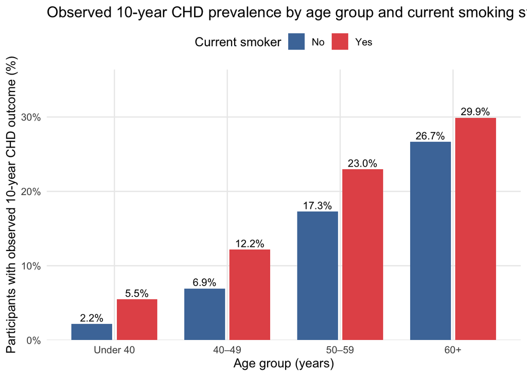

```r
ggplot(
  summary_table,
  aes(
    x = age_group,
    y = chd_prevalence,
    fill = smoking_status
  )
) +
  geom_col(
    position = position_dodge(width = 0.8),
    width = 0.72
  ) +
  geom_text(
    aes(label = percent(chd_prevalence, accuracy = 0.1)),
    position = position_dodge(width = 0.8),
    vjust = -0.35,
    size = 3.5
  ) +
  scale_fill_manual(
    values = c("#4C78A8", "#E45756")
  ) +
  scale_y_continuous(
    labels = percent_format(accuracy = 1),
    limits = c(0, 0.35),
    expand = expansion(mult = c(0, 0.04))
  ) +
  labs(
    title = paste(
      "Observed 10-year CHD prevalence by age group",
      "and current smoking status"
    ),
    x = "Age group (years)",
    y = "Participants with observed 10-year CHD outcome (%)",
    fill = "Current smoker"
  ) +
  theme_minimal(base_size = 12) +
  theme(
    legend.position = "top",
    panel.grid.minor = element_blank()
  )
```

# Interpretation

The chart above shows the observed 10-year CHD prevalence by age group and current smoking status. The data shows that overall 10 year CHD was increasingly more prevelant for the older participants, prevalence ranged from 2.2-5.5% for participants under 40 and 26.7-29.9% for participants 60 or older. It also shows that within each age groups, the prevelance of CHD was higher for participants who are current smokers, the largest difference was 5.7 percentage points for participants who 50-59.